# Working with Jupyter Notebook

The following example is based on Script `Descr-Figures` from Chapter 2 and demonstrates the use of **Jupyter Notebooks** to document your work step by step. We will describe the two most important building blocks:

- basic Markdown commands to format your text in `Markdown` cells
- how to import and run Python code in `Code` cells

## Import and Prepare Data

Let's start by importing all external modules:

```python
import wooldridge as woo
import numpy as np
import pandas as pd
import matplotlib.pyplot as plt
```

In the next step, we import our data and define important variables:

```python
affairs = woo.dataWoo('affairs')

# use a pandas.Categorical object to attach labels:
affairs['haskids'] = pd.Categorical.from_codes(affairs['kids'],
                                               categories=['no', 'yes'])
counts = affairs['haskids'].value_counts()
```

## Analyse Data

### View your Data

To get an overview you could use `affairs.head()`.

### Calculate Descriptive Statistics

Up to this point, the code cells above produced no output. This will change now, as we are interested in some results. Let's start with printing out the average age. We start with its definition and use LaTeX to enter the equation: $$ \bar{x} = \frac{1}{N} \sum_{i=1}^N x_{i} $$ The resulting Python code gives:

```python
age_mean = np.mean(affairs['age'])
print(age_mean)
```

```
32.48752079866888
```

### Produce Graphic Results

In Chapter 2, we saw how to produce a pie chart. Let's repeat it here:

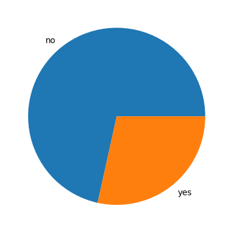

```python
plot = plt.pie(counts, labels=['no', 'yes'])
```

You can also show Python code without executing it. You can use `inline code`, or for longer paragraphs

```
plt.bar(['no', 'yes'], counts, color='dimgrey')
```